# Superspreaders and TB

2020-03-03 10:17:56

## Motivation

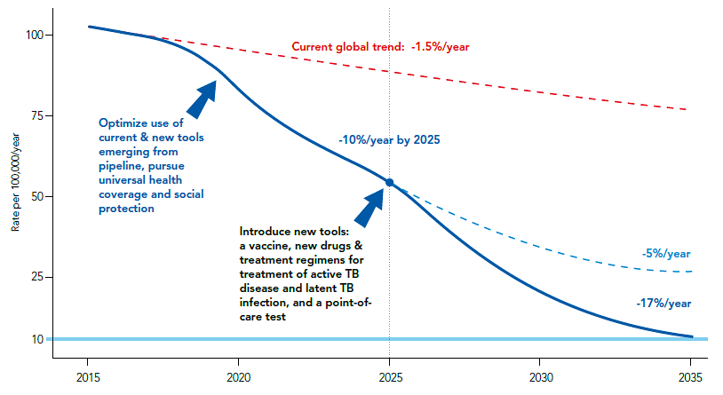

Source: WHO

## High-risk groups

- High risk of getting infected
- High risk of progressing to disease
- **High risk of transmission**

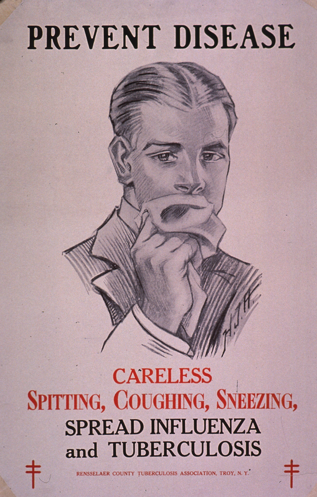

Source: NIH

## High-transmitters (superspreaders) of TB

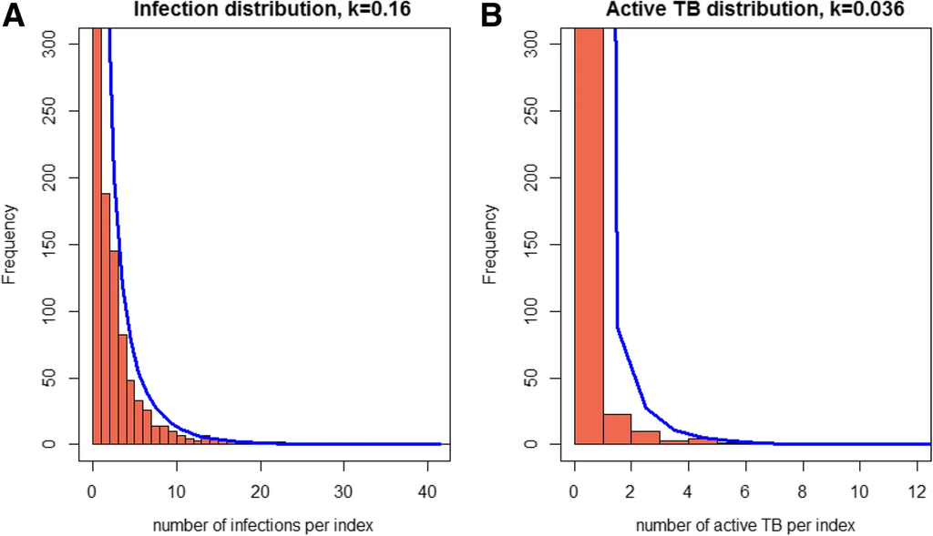

[Melsew et al 2019 BMC ID](https://doi.org/10.1186/s12879-019-3870-1).

## High-transmitters (superspreaders) of TB

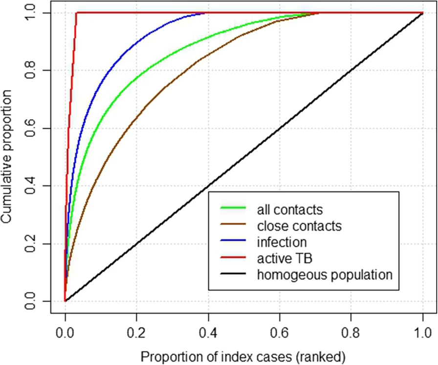

[Melsew et al 2019 BMC ID](https://doi.org/10.1186/s12879-019-3870-1).

## Transmission Potential

**Reproductive number = contact rate * infectiousness level * infectiousness duration**

## Contact (rate) heterogeneity

R = **contact rate** * infectiousness level * infectiousness duration

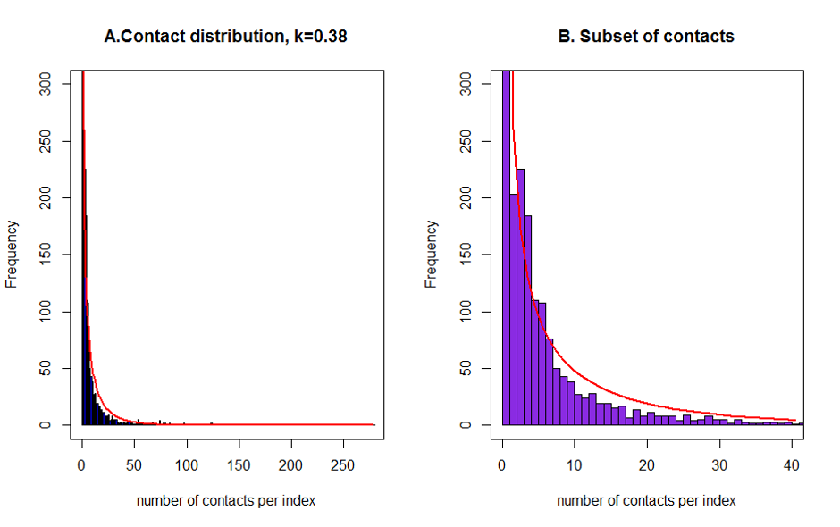

[Melsew et al 2019 BMC ID](https://doi.org/10.1186/s12879-019-3870-1).

## Infectiousness level heterogeneity

R = contact rate * **infectiousness level** * infectiousness duration

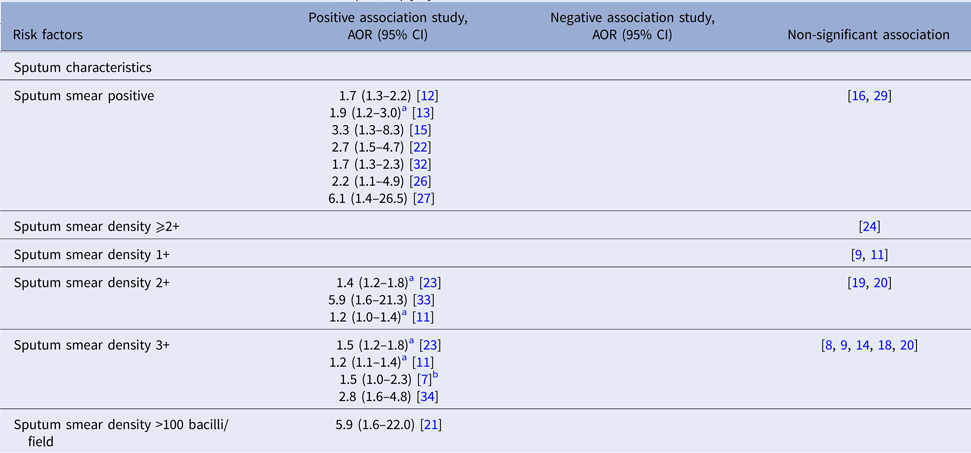

[Melsew et al 2018 Epi Inf](https://doi.org/10.1017/S0950268817003041).

## Infectiousness duration heterogeneity

R = contact rate * infectiousness level * **infectiousness duration**

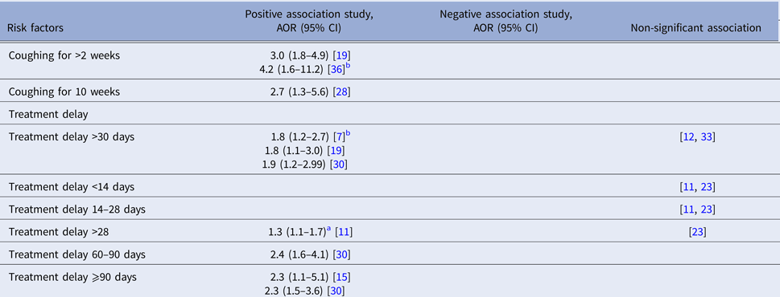

[Melsew et al 2018 Epi Inf](https://doi.org/10.1017/S0950268817003041).

## Cough duration heterogeneity

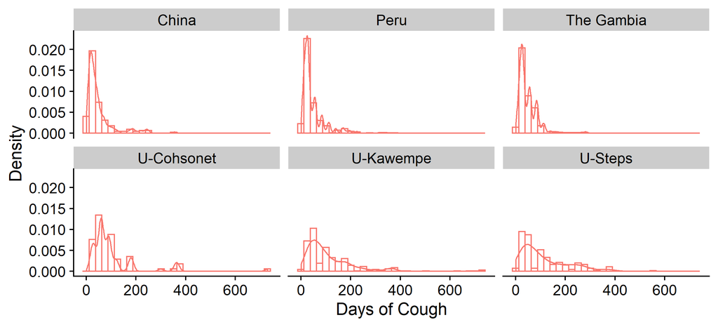

[Handel et al 2019 IJTLD](http://dx.doi.org/10.5588/ijtld.18.0819).

## Cough duration heterogeneity

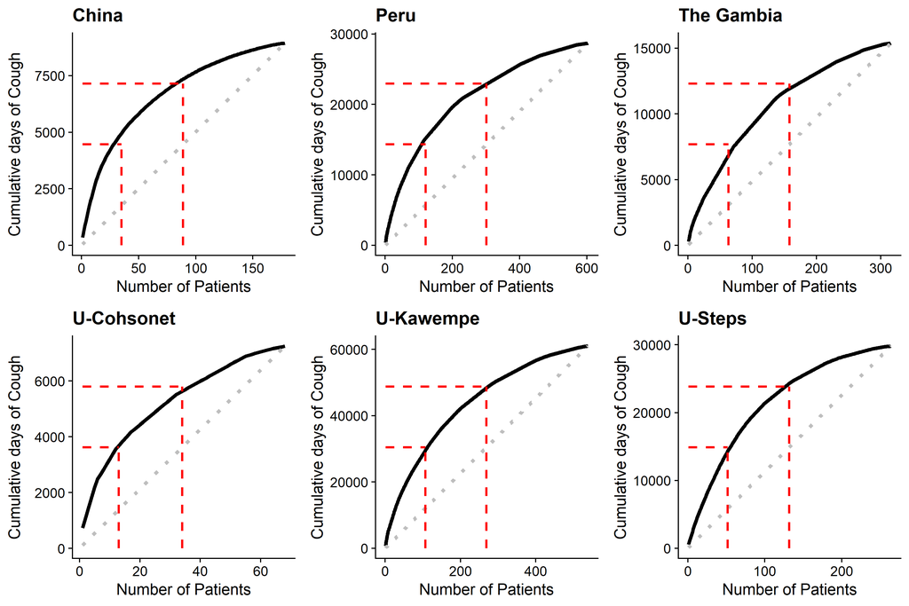

[Handel et al 2019 IJTLD](http://dx.doi.org/10.5588/ijtld.18.0819).

## Cough duration heterogeneity

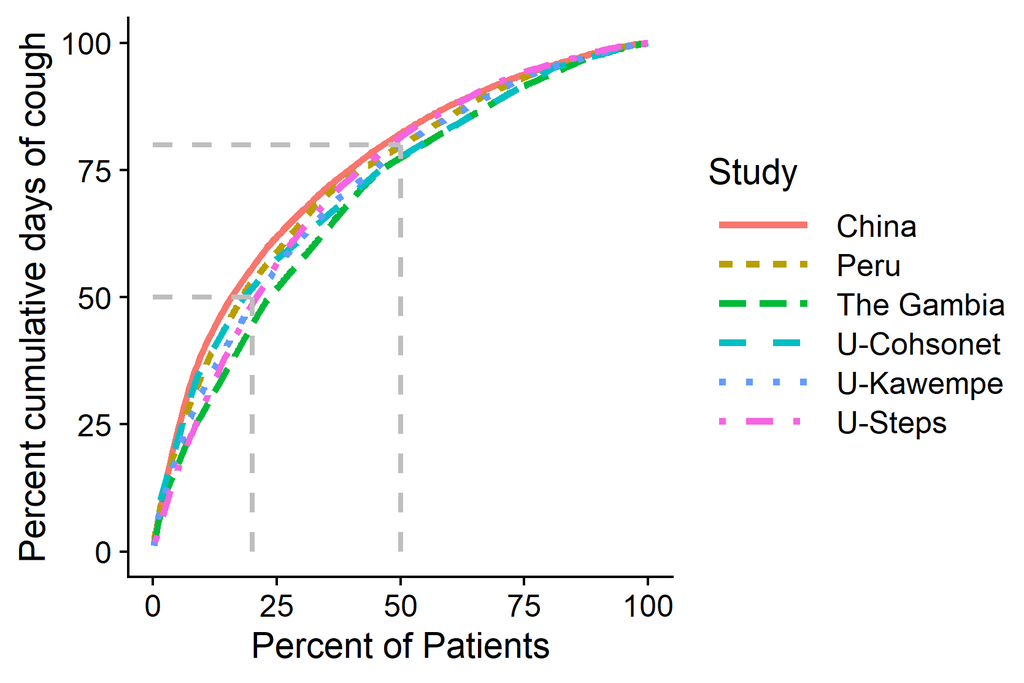

[Handel et al 2019 IJTLD](http://dx.doi.org/10.5588/ijtld.18.0819).

## What generates cough duration heterogeneity?

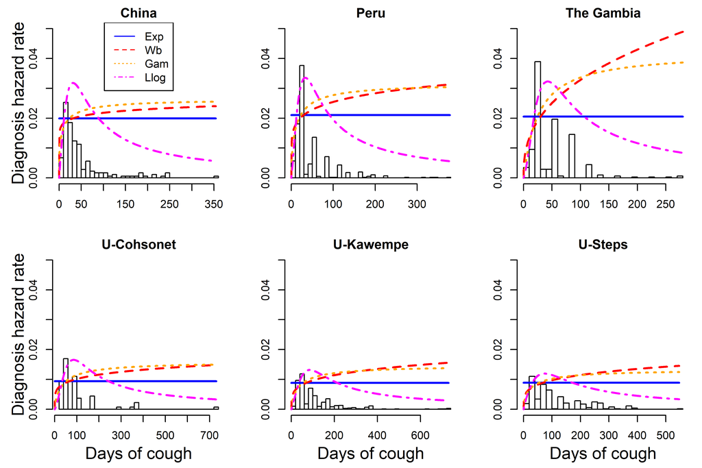

[Handel et al 2019 IJTLD](http://dx.doi.org/10.5588/ijtld.18.0819).

## What generates cough duration heterogeneity?

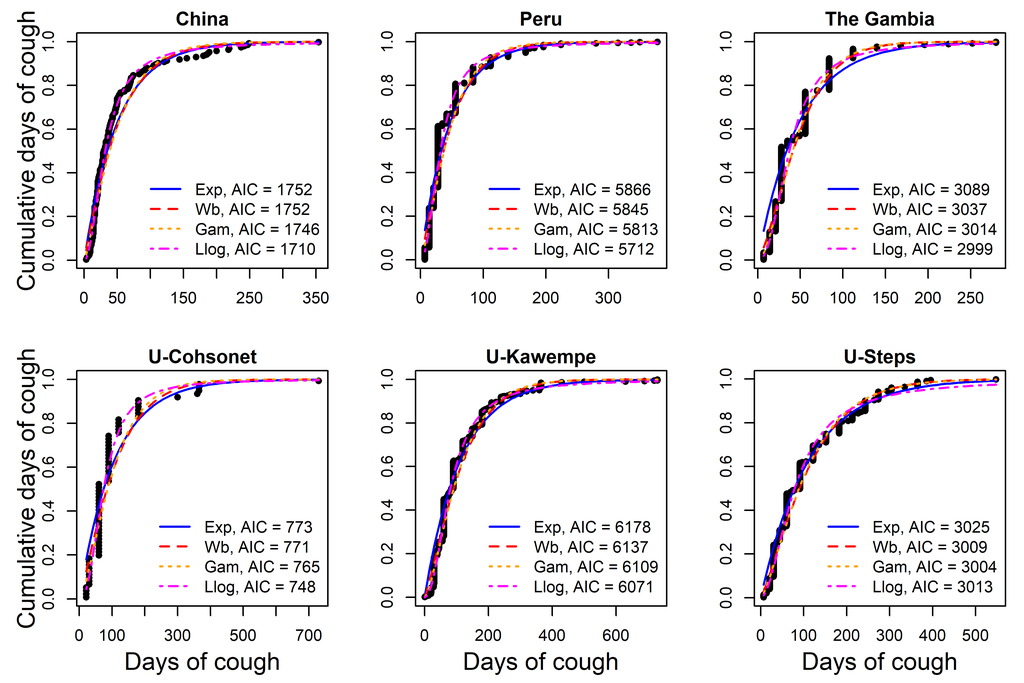

[Handel et al 2019 IJTLD](http://dx.doi.org/10.5588/ijtld.18.0819).

## Predictors of cough duration heterogeneity

- For each study, we fitted single-predictor and multi-variable models to cough duration outcome.
- Some of the individual predictors were statistically significant, but association with outcome was weak (low R<sup>2</sup>).
- Multi-variate models fitted in a predictive framework (cross-validation) also did not perform well, no predictive power.
- Single exception was U-Steps study, with variable “fraction visits to non TB healthcare providers” showing some correlation.

## Discussion

- There seems clear evidence that for TB - as for other diseases - there is heterogeneity in transmission potential.
- Heterogeneity is likely in all 3 components: contact rate/infectiousness level/infectiousness duration.
- Unclear how important each component is and if/how they co-vary.
- Unclear if one can practically identify high-transmitters/superspreaders.

## Discussion

- Melsew 2018, 2019, our study and many similar studies often find correlations between some variable and (proxies of) transmission.
- Those findings are not tested on independent data, thus hard to know how useful such variables are.
- To be useful, one would need to find **robust and actionable** variables.

## Thanks!

- Co-investigators: L Martinez, JN Sekandi, SE Bellan, L Zhu, C Chen, Q Liu, S Donkor, J Sutherland, PC Hill, RH Gilman, L Grandjean, CC Whalen
- Funding: NIH A1093856, NIH AI093856-05W1, The Wellcome Trust 201470/Z/16/Z, NIH K01AI125830, NIH AI-45244-95383.
- Contact: [My website](https://www.andreashandel.com/), Email: ahandel@uga.edu, Twitter: @andreashandel.

## Cough duration heterogeneity studies

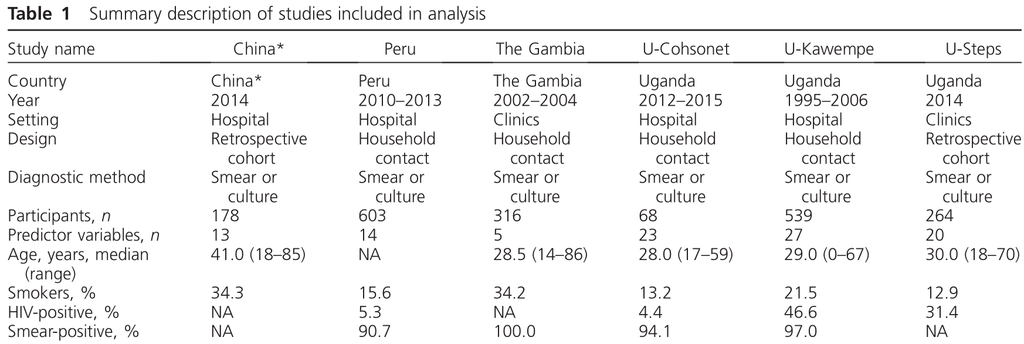

[Handel et al 2019 IJTLD](http://dx.doi.org/10.5588/ijtld.18.0819).